# Mapping all MRB to OTU Hu et al. 2018

Lisa Thönen

6/16/2022

Modified from “Hu et al. (2018), bacteria community analysis in R” published in Hu et al. 2018

# Background

We have sequenced the bacteria communities of a field experiment where WT and bx1 mutant plants were grown. From both plant lines, we have collected root and rhizosphere samples and profiled the bacteria communities using 16S rRNA sequencing.

The analysis of the bacteria communities in R requires the following input files:  
- Experimental design: *Database_S1.txt* (save Database S1 as tab-delimited text file)  
- OTU table: *both_exps_trimmed_qfiltered_renamed_l360_sort_derep_ab5_otu_chimerafree.tab*  
- Taxonomy: *SILVA_tax_forR.txt*

# Field experiment

The field experiment consistet of a total of 44 samples representing 5 sample groups (soil samples and rhizosphere and root samples of both wildtype B73 or *bx1* mutant plants). The number of replicates per sample group is given below.

| field_soil | WT_Rhizo | WT_Root | bx1_Rhizo | bx1_Root |
| --- | --- | --- | --- | --- |
| 10 | 10 | 10 | 7 | 7 |

## Identification of differentially abundant OTUs

In a second step, we identified both in rhizosphere and root samples OTUs that differed in their relative abundance between wildtype B73 and mutant *bx1*(B73) plants. For this analysis we focussed on the abundant OTUs similar to Bai et al. (2016, Nature). We defined abundant OTUs as OTUs that have a minimal average abundance of 0.1% in the dataset. We utilized the r-package ‘edgeR’ for this analysis as particular strengths of this tool are the ability to estimate biological dispersion between replicate samples, and the performance of exact tests of significance that are suitable for small counts. We estimated dispersion by weighted likelihood empirical Bayes, modeled the OTU abundances as a function for the five sample groups and we contrasted the two genotypes, both for rhizosphere and root samples for the likelyhood ratio tests. P-values were adjusted according to Benjamini and Hochberg (1995).

*Root samples: bOTUs differing between B73 and *bx1* plants*

Below we list the direction and taxonomies of the differentially abundant bOTUs (between B73 and *bx1* plants) in the root compartment. This information is comprised in the Database S4.

|  | lower.in.WT | unchanged | higher.in.WT |
| --- | --- | --- | --- |
| **1*design_field$groupsWT_Root -1*design_field$groupsbx1_Root** | 9 | 175 | 3 |

|  | phylum | genus |
| --- | --- | --- |
| **bOTU15** | Proteobacteria | Pseudomonas |
| **bOTU62** | Proteobacteria | Pantoea |
| **bOTU889** | Actinobacteria | Actinoplanes |
| **bOTU118** | Proteobacteria | Rhizobium |
| **bOTU79** | Bacteroidetes | Flavobacterium |
| **bOTU1612** | Proteobacteria | Pseudomonas |
| **bOTU233** | Proteobacteria | Delftia |
| **bOTU86** | Actinobacteria | uncultured |
| **bOTU12** | Proteobacteria | Rhizobium |
| **bOTU315** | Bacteroidetes | Flavobacterium |
| **bOTU158** | Proteobacteria | Stenotrophomonas |
| **bOTU121** | Actinobacteria | uncultured |

## Root bacterial communities in WT and bx1 plants

The 50 most abundant bOTUs in the root compartment are presented in the rank abundance plot below. The BX-dependent OTUs among the Top50 root bOTUs are marked with an asterisk.

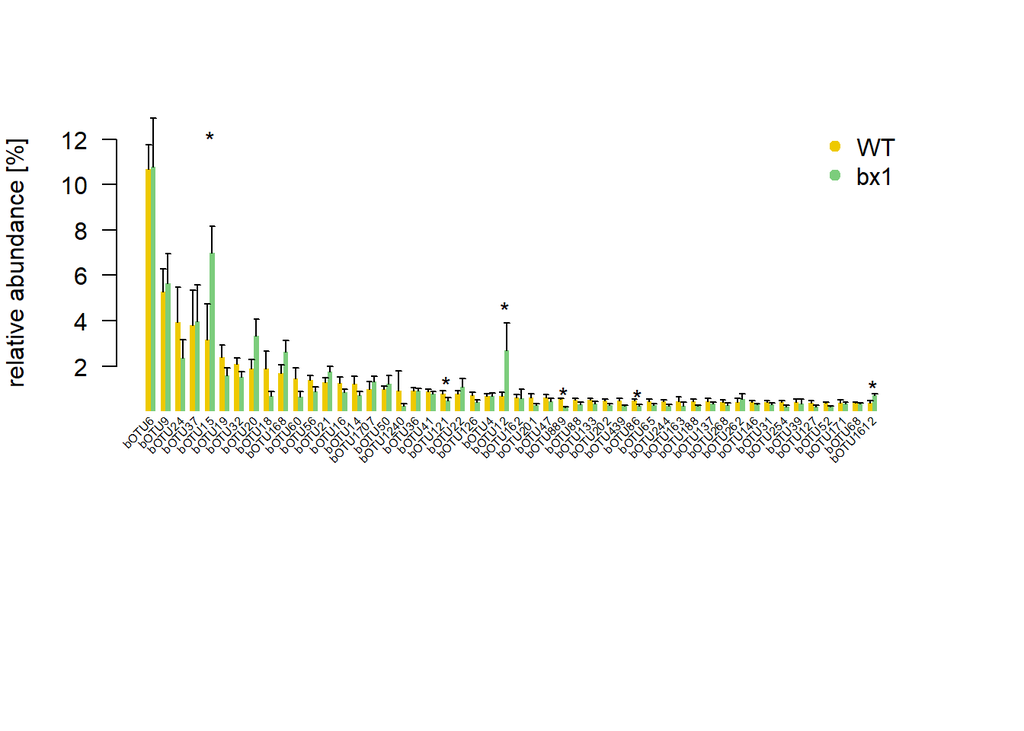

## Rhizosphere bacterial communities in WT and bx1 plants

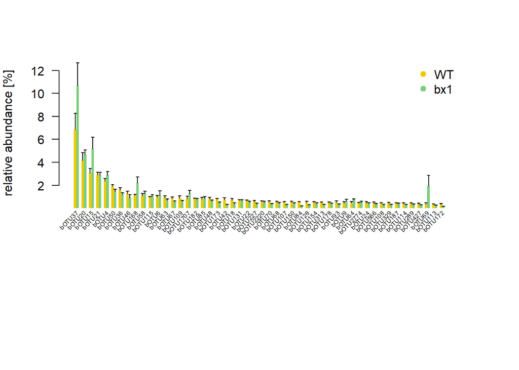

# Mapping bacterial isolate sequences to community sequences

We map the 16S rRNA gene seqeunces of the isolated strains to the OTUs of the maize root microbiome using the custom R script created by Jan Wälchli, which maps the 16s sequences and creates a similarity table for all hits > 97 %.

```
## [1] 135
```

```
## [1] 151
```

```
##  [1] "LAC11" "LBH2"  "LBH3"  "LBH7"  "LBO4"  "LBO6"  "LMA1"  "LMC3"  "LMF1"
## [10] "LMV1"  "LSP13" "LWH4"  "LWH8"  "LWH9"  "LWS12" "LWS2"
```

```
##       LAC11      LBH2      LBH3      LBH7      LBO4      LBO6      LMA1
## 1 0.9166667 0.9555556 0.9555556 0.9555556 0.9555556 0.9555556 0.9555556
##        LMC3      LMF1      LMV1     LSP13      LWH4      LWH8      LWH9
## 1 0.9555556 0.9694444 0.9694444 0.9555556 0.9555556 0.9555556 0.9555556
##       LWS12      LWS2
## 1 0.9555556 0.9694444
```

```
##       LAC11      LBH2      LBH3      LBH7      LBO4      LBO6      LMA1
## 1 0.7928177 0.9527778 0.9527778 0.9527778 0.9527778 0.9527778 0.9527778
## 2 0.7928177 0.9361111 0.9361111 0.9361111 0.9361111 0.9361111 0.9361111
## 3 0.8011050 0.9416667 0.9416667 0.9416667 0.9416667 0.9416667 0.9416667
## 4 0.7928177 0.9527778 0.9527778 0.9527778 0.9527778 0.9527778 0.9527778
## 5 0.7845304 0.9555556 0.9555556 0.9555556 0.9555556 0.9555556 0.9555556
##        LMC3      LMF1      LMV1     LSP13      LWH4      LWH8      LWH9
## 1 0.9555556 0.7651934 0.7664835 0.9527778 0.9527778 0.9527778 0.9527778
## 2 0.9388889 0.7734807 0.7857143 0.9361111 0.9361111 0.9361111 0.9361111
## 3 0.9444444 0.7624309 0.7719780 0.9416667 0.9416667 0.9416667 0.9416667
## 4 0.9555556 0.7624309 0.7637363 0.9527778 0.9527778 0.9527778 0.9527778
## 5 0.9555556 0.7513812 0.7527473 0.9555556 0.9555556 0.9555556 0.9555556
##       LWS12      LWS2
## 1 0.9527778 0.9638889
## 2 0.9361111 0.9527778
## 3 0.9416667 0.9555556
## 4 0.9527778 0.9694444
## 5 0.9555556 0.9555556
```

```
##       OTU Strain
## 1 bOTU143  LWS15
## 2 bOTU153  LWS13
## 3 bOTU564  LWS11
## 4  bOTU14  LWS11
## 5 bOTU143   LWS1
## 6 bOTU153   LWO8
```

### selection of best mapping OTUs

criteria: 1. Similarity 2. Abundance